# BIOC557: Human pancreatic islets: three molecular views

A complete default analysis in R

# 1 Start here

This report runs one fixed set of starting settings. Every data file is included in the teaching package. There is no parameter menu to complete.

For your first run, open **BIOC557.Rproj**, open **START_HERE.R**, and click **Source** in RStudio. It installs the missing packages and builds this report. After that, open **BIOC557_Default_Lab.Rmd** and click **Knit**.

The code below is written in small steps. Read a section, look at its plot, and use the short question to think about what the measurements show.

# 2 Read the demo data

Protein and RNA measurements use the same sample identifiers. Metabolite measurements, when present, follow those sample identifiers too.

```r
course <- read_course_study()
study <- course$study
settings <- course$settings

knitr::kable(course_settings_table(course))
```

| Setting | Value |
| --- | --- |
| Dataset | Human pancreatic islets: three molecular views |
| Matched samples | 6 |
| Analysis | Principal Component Analysis (PCA) |
| MOFA factors | Not used |
| Model features per view | 100 |
| Feature scaling | unit_variance |
| Protein/RNA alignment | Same gene IDs; same column order |
| Center features | Yes |
| Scale whole views | No |
| Seed | 557 |
| Maximum iterations | Not used |

The sample table tells us which measurements belong together.

```r
knitr::kable(head(study$metadata[, c("sample_id", "group")]))
```

| sample_id | group |
| --- | --- |
| RRID:SAMN08785739 | Non-diabetic |
| RRID:SAMN08786368 | Non-diabetic |
| RRID:SAMN08786387 | Non-diabetic |
| RRID:SAMN08783900 | T2D |
| RRID:SAMN08784303 | T2D |
| RRID:SAMN08784381 | T2D |

# 3 Prepare the molecular views

The supplied measurements are already on their published logarithmic scales. We keep features that pass the missingness filter, select the default variable features, and apply the selected scaling. Protein and RNA use the same genes in the same column order.

```r
lab <- run_lab(study,
               max_missing = settings$max_missing,
               model_features = settings$model_features,
               feature_scaling = settings$feature_scaling,
               feature_alignment = "matched_genes",
               mofa_center = settings$mofa_center)

knitr::kable(course_qc_table(lab))
```

| View | Samples | Input_features | Retained_features | Model_features | Missing_percent |
| --- | --- | --- | --- | --- | --- |
| Proteomics | 6 | 1200 | 910 | 100 | 12.6 |
| RNA | 6 | 1200 | 1200 | 100 | 0.0 |
| Metabolomics | 6 | 1200 | 584 | 100 | 25.9 |

## 3.1 Check missing measurements

Each bar shows the fraction of missing input measurements in one sample.

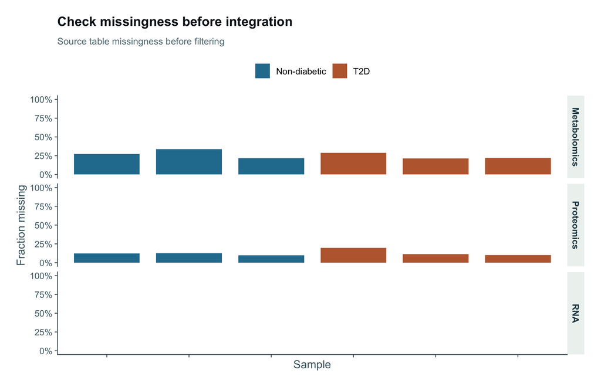

```r
quality_plot <- plot_quality(lab)
course_save_figure(quality_plot, "01_missingness")
```

**Think about it:** Which molecular view has the most missing measurements?

# 4 Look at each view with PCA

Principal Component Analysis (PCA) reduces many features to a few axes. Each point is one matched sample. Colors show the study groups after the axes have been calculated.

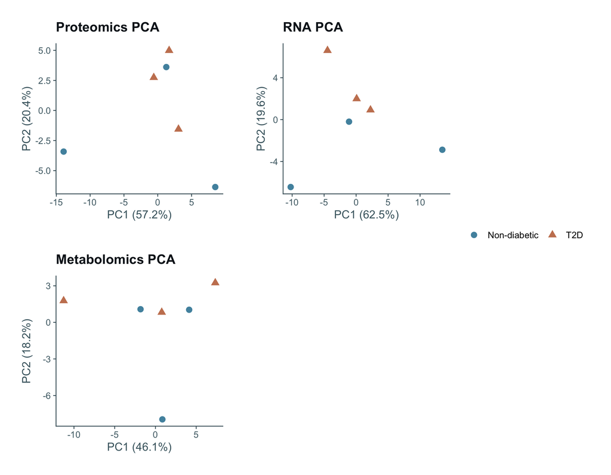

```r
pca_plot <- course_pca_panel(lab)
course_save_figure(pca_plot, "02_single_view_pca", height=7)
```

## 4.1 Combine the views with joint PCA

The joint matrix puts the molecular views side by side and balances their feature counts. The axes below describe the combined measurements.

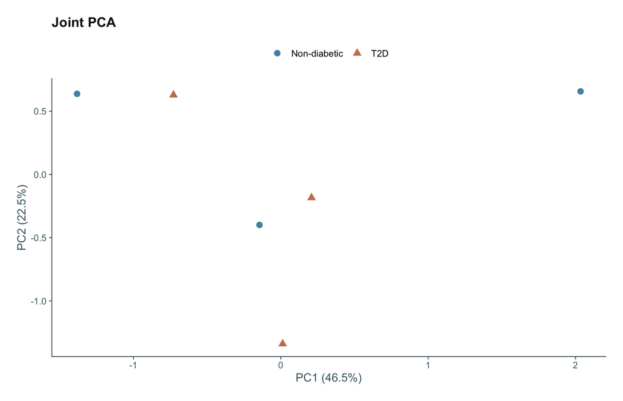

```r
joint_plot <- course_joint_pca(lab)
course_save_figure(joint_plot, "03_joint_pca")
```

**Think about it:** Do the separate views tell a similar story about the samples?

# 5 Compare RNA and protein for one gene

Each point pairs the RNA and protein measurement of the same gene in the same sample. The default gene is selected from genes present in both views.

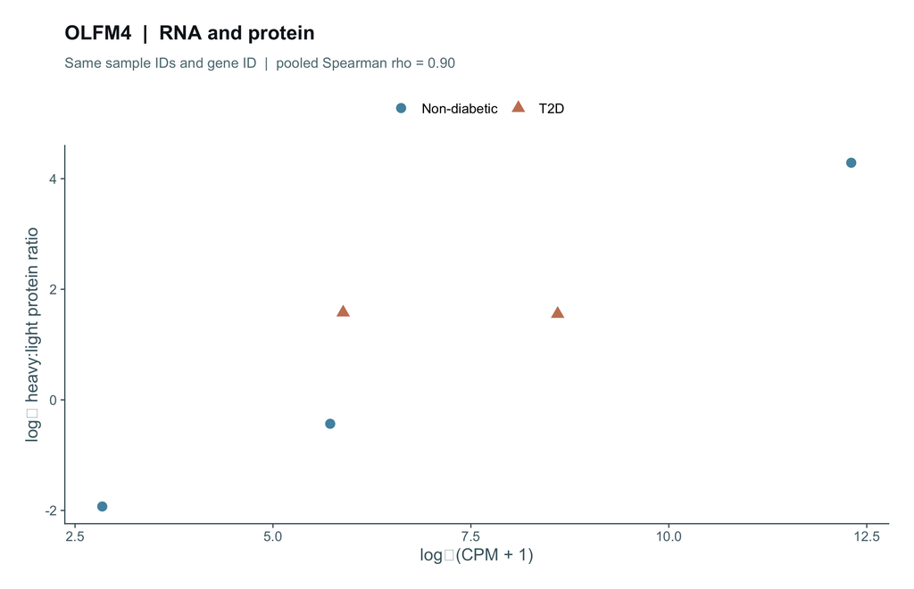

```r
gene_plot <- plot_gene_pair(lab)
course_save_figure(gene_plot, "04_rna_protein_gene")
```

**Think about it:** Do high RNA measurements always go with high protein measurements?

# 6 See the aligned feature matrix

Rows are features and columns are samples. Values are scaled within each feature for this display. Gray cells are missing observations.

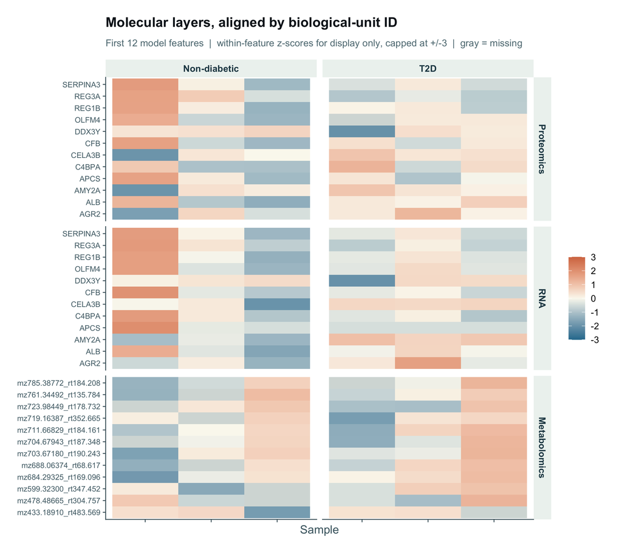

```r
feature_plot <- plot_feature_heatmap(lab)
course_save_figure(feature_plot, "05_feature_heatmap", height=8)
```

# 7 Read the default PCA result

This demo has six matched donors. Its default analysis uses Principal Component Analysis (PCA). The report keeps that starting analysis throughout. Protein and RNA genes are aligned by identifier. Untargeted metabolite features keep their measured mass-to-charge ratio and retention-time identifiers.

```r
knitr::kable(data.frame(
  Component = paste0("PC", seq_along(lab$joint_pca$explained)),
  Variance_percent = round(100 * lab$joint_pca$explained, 1)))
```

| Component | Variance_percent |
| --- | --- |
| PC1 | 46.5 |
| PC2 | 22.5 |
| PC3 | 13.1 |

**Think about it:** Which molecular view contributes most to the visible sample pattern? Compare the single-view plots with the joint PCA.

# 8 Save the completed analysis

The report saves the selected model matrices, gene alignment, sample metadata, result tables, settings and R session information. Each plotted figure also has PNG, PDF and SVG copies in **outputs/figures/**. PNG is a raster image, PDF is Portable Document Format, and SVG is Scalable Vector Graphics.

```r
course_save_results(course, lab, NULL)
knitr::kable(data.frame(File=list.files("outputs/figures", pattern="\\.png$")))
```

| File |
| --- |
| 01_missingness.png |
| 02_single_view_pca.png |
| 03_joint_pca.png |
| 04_rna_protein_gene.png |
| 05_feature_heatmap.png |

The HTML report can be opened in a browser after the analysis finishes. The **outputs/default_analysis.rds** file stores the analysis objects in R’s serialized data format. The **outputs/run_manifest.json** file records the settings, sample and gene identifiers, and software versions in JavaScript Object Notation (JSON). CSV means comma-separated values; it is the format used for the result tables.

# 9 Data sources

- [Multiomics Analysis Reveals Insights into Potential Drivers of Pancreatic Islet Pathology in Type 2 Diabetes](https://doi.org/10.1021/acsomega.4c10637). *ACS Omega*, 2025.

The default report uses principal component analysis throughout.

**One-minute recap:** We matched the samples, checked the measurements, compared the molecular views, and summarized their main patterns. Pick one plot and explain its axes and one result to a classmate.